# HW 4

### Enter your name and EID here: srs5826

**You will submit this homework assignment as a HTML file on Canvas.**

*For all questions, include the R commands/functions that you used to find your answer (show R chunk). Answers without supporting code will not receive credit. Write full sentences to describe your findings.*

### Question 1: (2 pts)

All subsequent code will be done using `dplyr`, so we need to load this package. We also want to look at the `penguins` dataset which is inside the `palmerpenguins` package:

```r
# Call dplyr and ggplot2 packages within tidyverse
library(tidyverse)

# Paste and run the following uncommented code into your console:
# install.packages("palmerpenguins")

# Save the data as a dataframe
penguins <- as.data.frame(palmerpenguins::penguins)
```

Using a `dplyr` function, pick all the rows/observaions in the `penguins` dataset from the year 2007 and save the result as a new object called `penguins_2007`. Compare the number of observations/rows in the original `penguins` dataset with your new `penguins_2007` dataset.

```r
#use dplyr function filter() to make a df that contains only penguins in the year 2007
penguins_2007 <- penguins %>%
  filter(year == 2007)
```

**There are 110 rows in the 2007 df compared to the 344 rows in the original df.**

### Question 2: (2 pts)

Using `dplyr` functions on `penguins_2007`, report the number of observations for each species-island combination (note that you’ll need to `group_by`). Which species appears on all three islands?

```r
#Use group_by() dplyr function to find all (species, island) combos
penguins_2007_combos <- penguins_2007 %>%
  group_by(species, island) %>%
  #use summarize(Count = n()) to get the number of observations of each combo
  summarize(Count = n())
```

**The species Adelie appears on all three islands.**

### Question 3: (2 pts)

Using `dplyr` functions on `penguins_2007`, create a new variable that contains the ratio of `bill_length_mm` to `bill_depth_mm` (call it `bill_ratio`). *Once you checked that your variable is created correctly*, overwrite `penguins_2007` so it contains this new variable.

```r
#use dplyr function mutate() to add a varaible of bill_ratio
penguins_2007 <- penguins_2007 %>%
  mutate(bill_ratio = bill_length_mm / bill_depth_mm)
```

Are there any cases in the `penguins_2007` dataset for which the `bill_ratio` exceeds 3.5? If so, for which species of penguins is this true?

```r
# Filter for cases where bill_ratio exceeds 3.5
high_ratio_cases <- penguins_2007 %>%
  filter(bill_ratio > 3.5)

# Get each species in these cases
species_above_3.5 <- unique(high_ratio_cases$species)
# Print the cases and species with high bill_ratio
print(species_above_3.5)
```

```
## [1] Gentoo
## Levels: Adelie Chinstrap Gentoo
```

**Only Gentoo gets printed, so this condition is only true for Gentoo penguins.**

### Question 4: (2 pts)

Using `dplyr` functions on `penguins_2007`, find the three penguins with the smallest bill ratio for *each species*. Only display the information about `species`, `sex`, and `bill_ratio`. Does the same sex has the smallest bill ratio across species?

```r
smallest_ratios <- penguins_2007 %>%
  #Do a group by to get each species
  group_by(species) %>%
  #select the three rows (or penguins) with the smallest bill ratio (I'm unsure of the instructions so just change to n=1 if you want 1 from each species)
  slice_min(order_by = bill_ratio, n = 3) %>%
  #use a select statement to get the species,sex, and bill_ratio
  select(species, sex, bill_ratio)
```

**The same sex does not have the samllest bill ratio. I was unsure about the instructions being find 3 penguins from each species or not, but it does not matter. The Chinstrap species is a female while the other two smallest bill ratios are male.**

### Question 5: (2 pts)

Using `dplyr` functions on `penguins_2007`, calculate the mean and standard deviation of `bill_ratio` for each species. Drop NAs from `bill_ratio` for these computations (e.g., using the argument `na.rm = T`) so you have values for each species. Which species has the greatest mean `bill_ratio`?

```r
# Group by species, calculate mean and sd, and drop NAs
penguins_2007_center_and_spread <- penguins_2007 %>%
  group_by(species) %>%
  summarize(
    mean_bill_ratio = mean(bill_ratio, na.rm = T),
    sd_bill_ratio = sd(bill_ratio, na.rm = T)
  )
```

**Gentoo’s have the greatest mean bill_ratio.**

### Question 6: (2 pts)

Using `dplyr` functions on `penguins_2007`, remove missing values for `sex`. Pipe a `ggplot` to create a single plot showing the distribution of `body_mass_g` colored by male and female penguins, faceted by species (use the function `facet_wrap()` with the option `nrow =` to give each species its own row). Which species shows the least sexual dimorphism (i.e., the greatest overlap of male/female size distributions)?

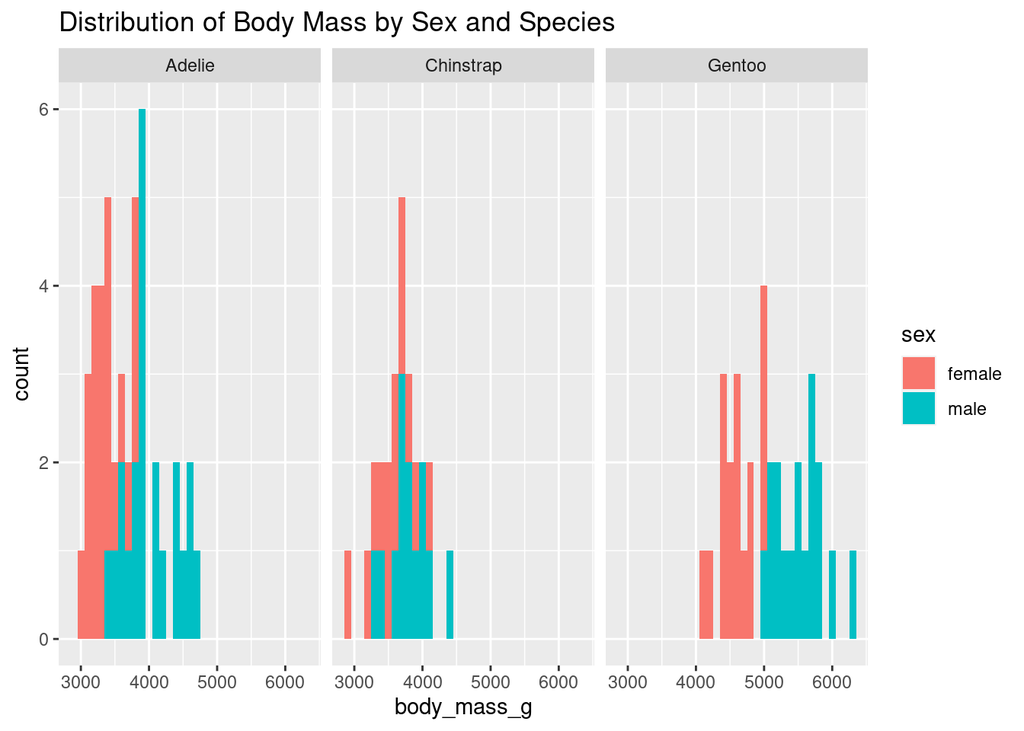

```r
# Remove NAs for 'sex'
penguins_2007 <- penguins_2007 %>%
  filter(!is.na(sex))

# Create a ggplot and facet by species colored by sex
ggplot(penguins_2007, aes(x = body_mass_g, fill = sex)) +
  geom_histogram(binwidth = 100) +
  facet_wrap(~species, nrow = 1) +
  labs(title = "Distribution of Body Mass by Sex and Species")
```

**Chinstrap penguins seem to overlap the most, therefore shows the least sexual dimorphism.**

### Question 7: (2 pts)

Pipe a `ggplot` to `penguins_2007` to create a scatterplot of `body_mass_g` (y-axis) against `bill_ratio` (x-axis). Does it look like there is a relationship between the bill ratio and the body mass? *Note: you might see a Warning message.* What does this message refer to?*

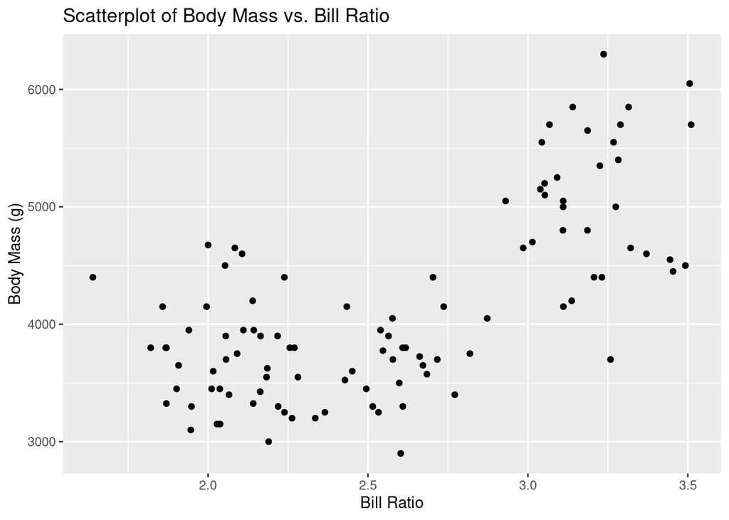

```r
# Create a scatterplot
penguins_2007 %>%
  ggplot(aes(x = bill_ratio, y = body_mass_g)) +
  #add points
  geom_point() +
  #labels
  labs(
    x = "Bill Ratio",
    y = "Body Mass (g)",
    title = "Scatterplot of Body Mass vs. Bill Ratio"
  )
```

**There seems to be some positive correlation between bill ratio and body mass in g, but only at the last third of the graph. Before that, it seems like no correlation. I did not get an error message but the message may have been a warning message referring to the correlation at the end but not the start.**

### Question 8: (2 pts)

What if we separate each species? Duplicate the plot from the previous question and add a regression trend line with `geom_smooth(method = "lm")`. Color the points and the regression lines by species. Does the relationship between the bill ratio and the body mass changes within each species?

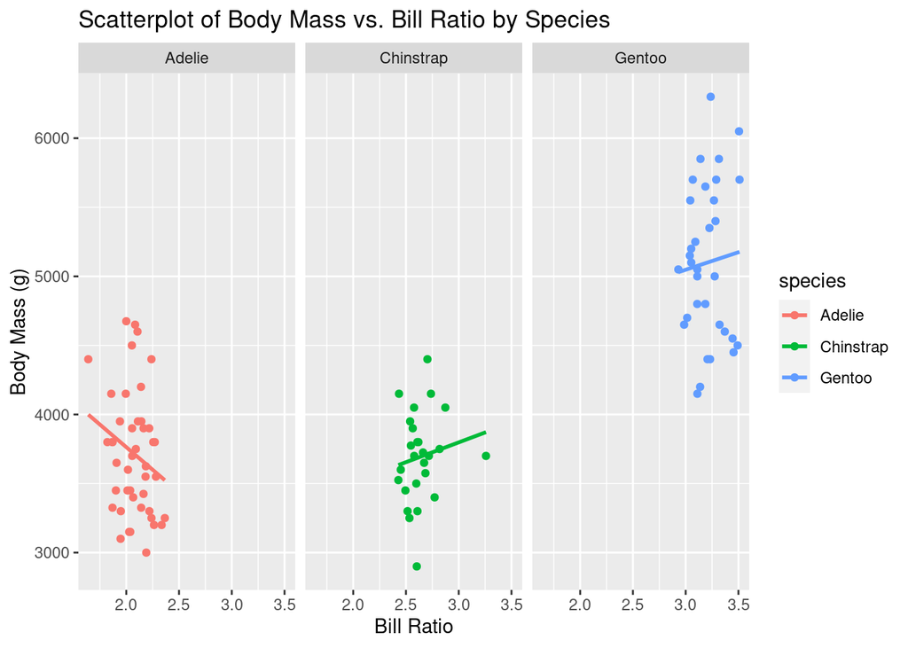

```r
penguins_2007 %>%
  #create graph
  ggplot(aes(x = bill_ratio, y = body_mass_g, color = species)) +
  #add poinrs
  geom_point() +
  #add lines
  geom_smooth(method = "lm", se = FALSE) +
  #color by species
  facet_wrap(~species) +
  labs(
    x = "Bill Ratio",
    y = "Body Mass (g)",
    title = "Scatterplot of Body Mass vs. Bill Ratio by Species"
  )
```

**The relationship between the bill ratio and the body mass does change within each species. Adelie is negatively correlated. Chinstrap is slightly positively correlated. Gentoo is also slightly positvely correlated. This explains the previous scatterplot. The correlations cancel out eachother to get no correlation, however, the Gentoo penguins are very heavy so the end of the previous scatterplot shows a positive correlation.**

### Question 9: (2 pts)

Finally, let’s make a plot using the original `penguins` dataset (not just the 2007 data). Forewarning: This will be very busy plot!

Map `body_mass_g` to the y-axis, `flipper_length_mm` to the x-axis, `species` to color, and `island` to shape. Using `facet_wrap()`, facet the plots by `year`. Find a way to clean up the x-axis labels (e.g., reduce the amount of tick marks) using `scale_x_continuous()`. Does there appear to be a relationship between body mass and flipper length overall? Is there a relationship within each species? What happens to the distribution of flipper lengths for species over time?

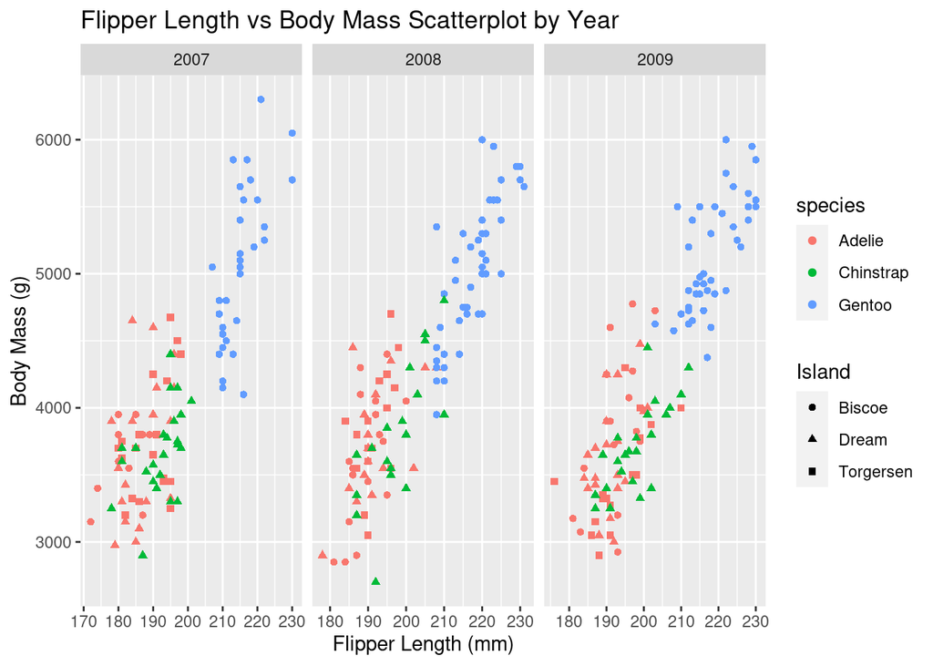

```r
penguins %>%
  #create plot color by species add island to shape
  ggplot(aes(x = flipper_length_mm, y = body_mass_g, color = species, shape = island)) +
  #add points
  geom_point() +
  #facet wrap by year
  facet_wrap(~year, scales = "free_x", nrow = 1) +
  #labels
  labs(
    x = "Flipper Length (mm)",
    y = "Body Mass (g)",
    title = "Flipper Length vs Body Mass Scatterplot by Year",
    shape = "Island"
  ) +
  #reduce tick marks
  scale_x_continuous(breaks = seq(160, 260, by = 10))
```

**There is a very positive correlation between flipper length and body mass among all three species. The distribution of flipper lengths stays relatively the same across all three years.**

### Formatting: (2 pts)

Comment your code, write full sentences, and knit your file!

[output not shown]